# 2.2 practice quiz - Критерий Стьюдента

## Критерии Стьюдента

```python
import numpy as np
import pandas as pd
import scipy
from scipy import stats
from statsmodels.stats.weightstats import *
from sklearn import cross_validation, linear_model, ensemble
```

```python
%pylab inline
```

### Question 4

Уровень кальция в крови здоровых молодых женщин равен в среднем 9.5 милиграммам на децилитр и имеет характерное стандартное отклонение 0.4 мг/дл. В сельской больнице Гватемалы для 160 здоровых беременных женщин при первом обращении для ведения беременности был измерен уровень кальция; среднее значение составило 9.57 мг/дл. Можно ли утверждать, что средний уровень кальция в этой популяции отличается от 9.5?

Посчитайте достигаемый уровень значимости. Поскольку известны только среднее и дисперсия, а не сама выборка, нельзя использовать стандартные функции критериев — нужно реализовать формулу достигаемого уровня значимости самостоятельно.

```python
mean = 9.5
sigma = 0.4

n = 160.0
sample_mean = 9.57
```

$H_0\colon$ среднее значение уровня кальция равно 9.5

$H_1\colon$ не равно

```python
z = (sample_mean - mean) / (sigma/np.sqrt(n))
z
```

```
2.213594362117875
```

```python
p_value = 2 * (1 - scipy.stats.norm.cdf(np.abs(z)))
p_value
```

```
0.026856695507523787
```

### Question 6

Имеются данные о стоимости и размерах 53940 бриллиантов. Отделите 25% случайных наблюдений в тестовую выборку с помощью функции sklearn.cross_validation.train_test_split (зафиксируйте random state = 1). На обучающей выборке настройте две регрессионные модели:

- линейную регрессию с помощью LinearRegression без параметров
- случайный лес с помощью RandomForestRegressor с random_state=1.

Какая из моделей лучше предсказывает цену бриллиантов? Сделайте предсказания на тестовой выборке, посчитайте модули отклонений предсказаний от истинных цен. Проверьте гипотезу об одинаковом среднем качестве предсказаний, вычислите достигаемый уровень значимости. Отвергается ли гипотеза об одинаковом качестве моделей против двусторонней альтернативы на уровен значимости α=0.05?

```python
data = pd.read_csv('data/diamonds.txt', sep='\t')
```

```python
data.head()
```

|  | carat | depth | table | price | x | y | z |
| --- | --- | --- | --- | --- | --- | --- | --- |
| 0 | 0.23 | 61.5 | 55.0 | 326 | 3.95 | 3.98 | 2.43 |
| 1 | 0.21 | 59.8 | 61.0 | 326 | 3.89 | 3.84 | 2.31 |
| 2 | 0.23 | 56.9 | 65.0 | 327 | 4.05 | 4.07 | 2.31 |
| 3 | 0.29 | 62.4 | 58.0 | 334 | 4.20 | 4.23 | 2.63 |
| 4 | 0.31 | 63.3 | 58.0 | 335 | 4.34 | 4.35 | 2.75 |

```python
data_price = data['price'].values
data = data[['carat', 'depth', 'table', 'x', 'y', 'z']]
```

```python
train_data, test_data, train_price, test_price = cross_validation.train_test_split(
    data, data_price, test_size=0.25, random_state=1)
```

```python
model1 = linear_model.LinearRegression()
model1.fit(train_data, train_price)
model1_predictions = model1.predict(test_data)
```

```python
model2 = ensemble.RandomForestRegressor(random_state=1)
model2.fit(train_data, train_price)
model2_predictions = model2.predict(test_data)
```

```python
error1 = np.abs(test_price - model1_predictions)
error2 = np.abs(test_price - model2_predictions)
```

```python
sample_mean1 = np.mean(error1)
sample_mean1
```

```
890.3764004285592
```

```python
sample_mean2 = np.mean(error2)
sample_mean2
```

```
803.6143383081302
```

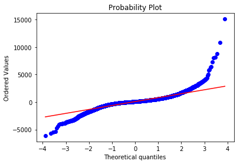

```python
stats.probplot(error1 - error2, dist='norm', plot=pylab)
pylab.show()
```

```python
stats.ttest_rel(error1, error2)
```

```
Ttest_relResult(statistic=12.930817614948603, pvalue=5.074175575671402e-38)
```

### Question 7

В предыдущей задаче посчитайте 95% доверительный интервал для разности средних абсолютных ошибок предсказаний регрессии и случайного леса. Чему равна его ближайшая к нулю граница? Округлите до десятков (поскольку случайный лес может давать немного разные предсказания в зависимости от версий библиотек, мы просим вас так сильно округлить, чтобы полученное значение наверняка совпало с нашим).

```python
DescrStatsW(error1 - error2).tconfint_mean()
```

```
(73.61008769457425, 99.91403654628368)
```